# Chapter 8 HW

Ulices Gonzalez

May 15th, 2025

## Conceptual Questions

### 3. This question relates to the plots in Figure 8.14.

#### (a) Sketch the tree corresponding to the partition of the predictor space illustrated in the left-hand panel of Figure 8.14. The numbers inside the boxes indicate the mean of Y within each region.

#### (b) Create a diagram similar to the left-hand panel of Figure 8.14, using the tree illustrated in the right-hand panel of the same figure. You should divide up the predictor space into the correct regions, and indicate the mean for each region.

## Applied Questions

### 8. In the lab, a classifcation tree was applied to the Carseats data set after converting Sales into a qualitative response variable. Now we will seek to predict Sales using regression trees and related approaches, treating the response as a quantitative variable.

#### (a) Split the data set into a training set and a test set.

```r
library(tree)
library(randomForest)
carseats <- read.csv("DataSets/Carseats.csv")
set.seed(1)
carSeatsTrain = sample(1:nrow(carseats), nrow(carseats) / 2)
carTrainSet = carseats[carSeatsTrain, ]
carTestSet = carseats[-carSeatsTrain,]
```

#### (b) Fit a regression tree to the training set. Plot the tree, and interpret the results. What test MSE do you obtain?

```r
carTree = tree(Sales~.,data = carTrainSet)
summary(carTree)
```

```
##
## Regression tree:
## tree(formula = Sales ~ ., data = carTrainSet)
## Variables actually used in tree construction:
## [1] "Price"       "Population"  "CompPrice"   "Income"      "Advertising"
## [6] "Age"         "Education"
## Number of terminal nodes:  18
## Residual mean deviance:  2.726 = 496.2 / 182
## Distribution of residuals:
##      Min.   1st Qu.    Median      Mean   3rd Qu.      Max.
## -4.361000 -1.092000  0.006545  0.000000  1.125000  4.989000
```

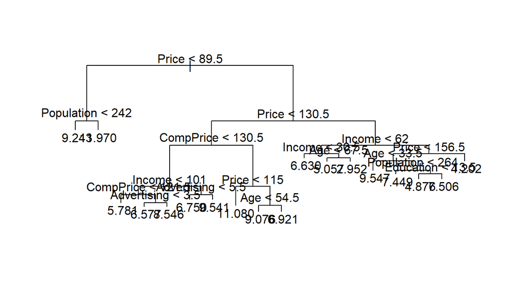

```r
plot(carTree)
text(carTree ,pretty =0)
```

```r
mean((predict(carTree,newdata = carTestSet) - carTestSet$Sales)^2)
```

```
## [1] 7.871697
```

#### (c) Use cross-validation in order to determine the optimal level of tree complexity. Does pruning the tree improve the test MSE?

```r
altCarSeats = cv.tree(carTree)
```

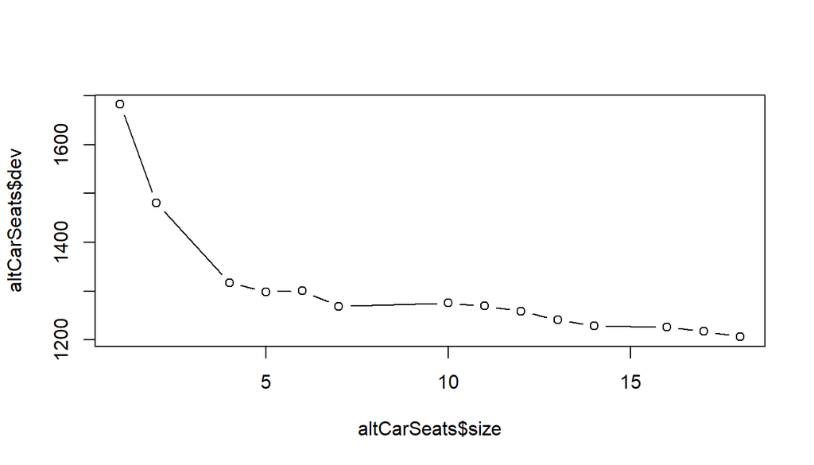

```r
plot(altCarSeats$size, altCarSeats$dev, type = "b")
```

[figure not shown]

```r
carTreePruned = prune.tree(carTree, best = 8)
plot(carTreePruned)
text(carTreePruned,pretty=0)
```

```r
mean((predict(carTreePruned,newdata = carTestSet) - carTestSet$Sales)^2)
```

```
## [1] 7.607696
```

#### (d) Use the bagging approach in order to analyze this data. What test MSE do you obtain? Use the importance() function to determine which variables are most important.

```r
carSeatsBag = randomForest(Sales~.,data=carTrainSet,mtry = 10, importance = TRUE)
mean((predict(carSeatsBag,newdata = carTestSet) - carTestSet$Sales)^2)
```

```
## [1] 3.090809
```

```r
importance(carSeatsBag)
```

```
##                %IncMSE IncNodePurity
## CompPrice   24.7575854     215.43043
## Income       6.8191334     109.95161
## Advertising  7.4901742      97.03162
## Population  -0.5077432      85.77853
## Price       51.6002288     527.70536
## ShelveLoc   26.8710880     235.46208
## Age         13.5783971     166.99652
## Education   -0.1412874      55.14556
## Urban        1.9902069      10.53419
## US           2.8038741      17.36050
```

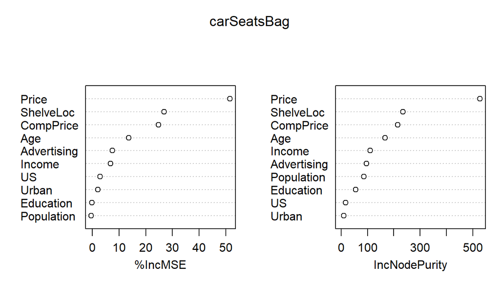

```r
varImpPlot(carSeatsBag)
```

#### (e) Use random forests to analyze this data. What test MSE do you obtain? Use the importance() function to determine which variables are most important. Describe the efect of m, the number of variables considered at each split, on the error rate obtained

```r
carSeatsForest = randomForest(Sales~.,data=carTrainSet,mtry = 3, importance = TRUE)
mean((predict(carSeatsForest,newdata = carTestSet) - carTestSet$Sales)^2)
```

```
## [1] 3.309537
```

```r
importance(carSeatsForest)
```

```
##                %IncMSE IncNodePurity
## CompPrice   13.7655035     159.33251
## Income       3.6678665     136.95752
## Advertising  6.2055659     117.30502
## Population  -2.0136414     114.04367
## Price       37.0896583     406.89139
## ShelveLoc   24.3620962     215.89157
## Age         12.9539510     184.16209
## Education   -0.7762981      86.64465
## Urban       -1.3538311      16.05842
## US           3.8410277      31.79657
```

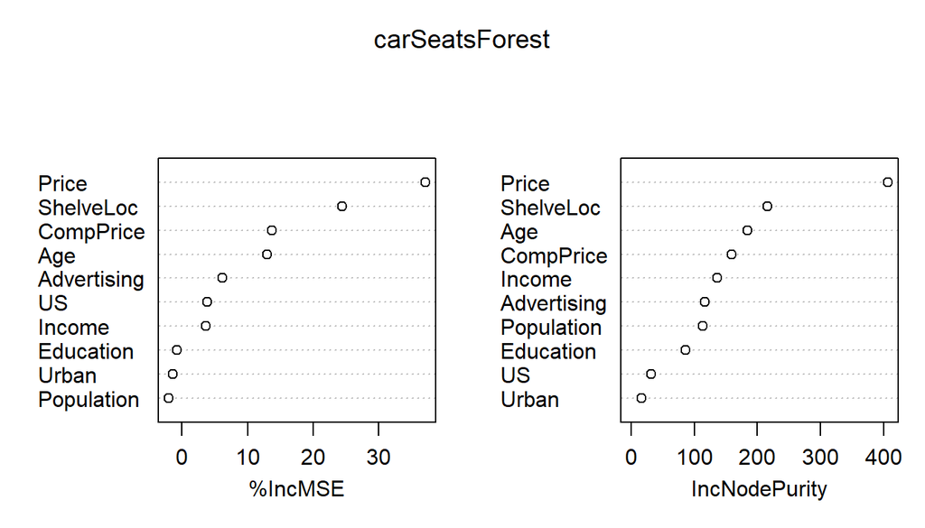

```r
varImpPlot(carSeatsForest)
```

### 10. We now use boosting to predict Salary in the Hitters data set.

#### (a) Remove the observations for whom the salary information is unknown, and then log-transform the salaries.

```r
library(gbm)
hitters <- read.csv("DataSets/Hitters.csv")
hitters = na.omit(hitters)
hitters$Salary = log(hitters$Salary)
```

#### (b) Create a training set consisting of the frst 200 observations, and a test set consisting of the remaining observations.

```r
hittersTrain = 1:200
hittersTrainSet = hitters[hittersTrain, ]
hittersTestSet = hitters[-hittersTrain,]

hittersTrainSet$League = as.factor(hittersTrainSet$League)
hittersTrainSet$Division = as.factor(hittersTrainSet$Division)
hittersTestSet$League = as.factor(hittersTestSet$League)
hittersTestSet$Division = as.factor(hittersTestSet$Division)
hittersTestSet$NewLeague = as.factor(hittersTestSet$NewLeague)
hittersTrainSet$NewLeague = as.factor(hittersTrainSet$NewLeague)
```

#### (c) Perform boosting on the training set with 1,000 trees for a range of values of the shrinkage parameter λ. Produce a plot with diferent shrinkage values on the x-axis and the corresponding training set MSE on the y-axis.

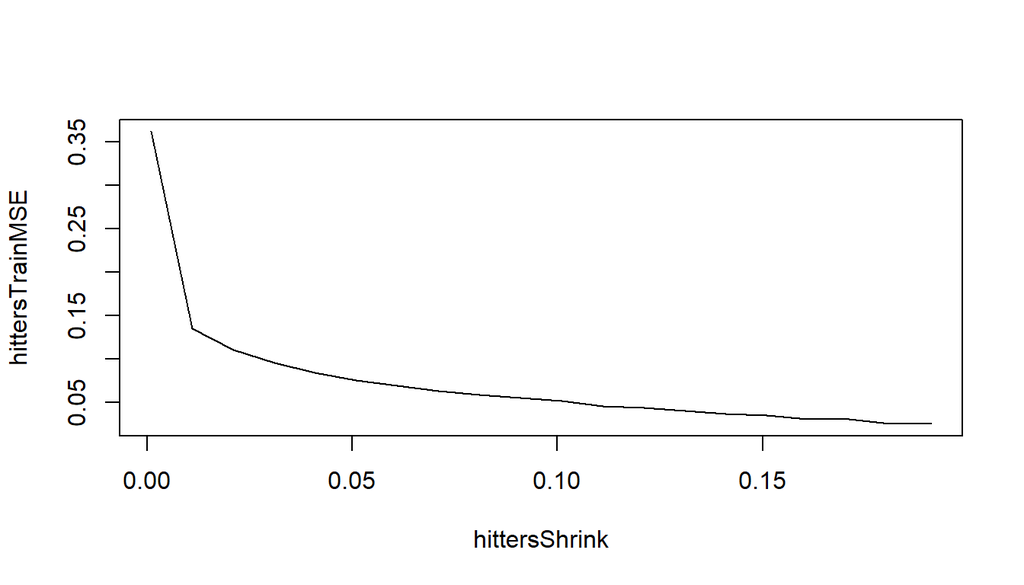

```r
hittersShrink = seq(0.001, 0.2, by = 0.01)
hittersTrainMSE = numeric(length(hittersShrink))

for (i in seq_along(hittersShrink))
{
  hittersBoost = gbm(Salary ~ ., data = hittersTrainSet, n.trees = 1000, shrinkage = hittersShrink[i], distribution = "gaussian", verbose = FALSE)
  hittersPredTrain = predict(hittersBoost, newdata = hittersTrainSet, n.trees = 1000)
  hittersTrainMSE[i] = mean((hittersPredTrain - hittersTrainSet$Salary)^2)
}

plot(hittersShrink, hittersTrainMSE, type = "l")
```

#### (d) Produce a plot with diferent shrinkage values on the x-axis and the corresponding test set MSE on the y-axis

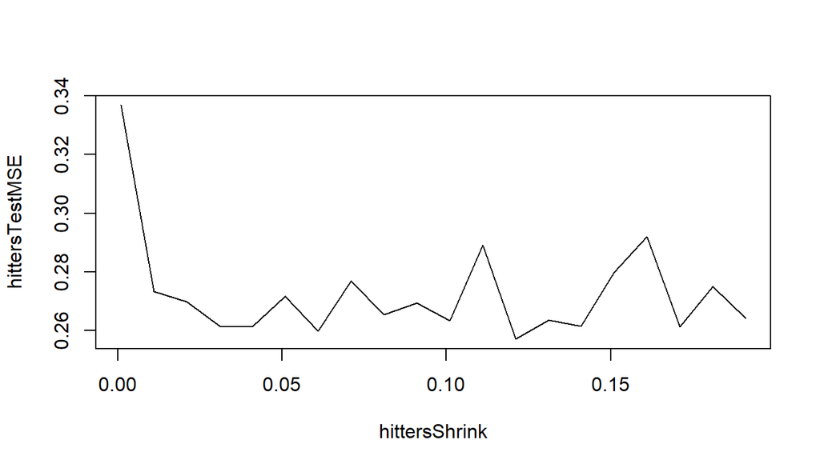

```r
hittersTestMSE = numeric(length(hittersShrink))

for (i in seq_along(hittersShrink))
{
  hittersBoost = gbm(Salary ~ ., data = hittersTrainSet, n.trees = 1000, shrinkage = hittersShrink[i], distribution = "gaussian", verbose = FALSE)
  hittersTestPred = predict(hittersBoost, newdata = hittersTestSet, n.trees = 1000)
  hittersTestMSE[i] = mean((hittersTestPred - hittersTestSet$Salary)^2)
}

plot(hittersShrink, hittersTestMSE, type = "l")
```

#### (e) Compare the test MSE of boosting to the test MSE that results from applying two of the regression approaches seen in Chapters 3 and 6.

```r
hittersLinear = lm(Salary ~ ., data = hittersTrainSet)
hittersLinearPred = predict(hittersLinear, newdata = hittersTestSet)
mean((hittersLinearPred - hittersTestSet$Salary)^2)
```

```
## [1] 0.4917959
```

```r
hittersColumns = sapply(hittersTrainSet, is.numeric)
hittersColNames = names(hittersTrainSet)[hittersColumns & names(hittersTrainSet) != "Salary"]
hittersFormula = as.formula(paste("Salary ~ . +", paste(paste0("I(", hittersColNames, "^2)"), collapse = " + ")))

hittersPolynomial = lm(hittersFormula, data = hittersTrainSet)
hittersPolynomialPred = predict(hittersPolynomial, newdata = hittersTestSet)
mean((hittersPolynomialPred - hittersTestSet$Salary)^2)
```

```
## [1] 0.3068952
```

#### (f) Which variables appear to be the most important predictors in the boosted model?

#### (g) Now apply bagging to the training set. What is the test set MSE for this approach?

```r
hittersTrainSet$League = as.factor(hittersTrainSet$League)
hittersTrainSet$Division = as.factor(hittersTrainSet$Division)
hittersTestSet$League = as.factor(hittersTestSet$League)
hittersTestSet$Division = as.factor(hittersTestSet$Division)

hittersBag = randomForest(Salary ~ ., data = hittersTrainSet, mtry = ncol(hittersTrainSet) - 1, importance = TRUE)
hittersBagPred = predict(hittersBag, newdata = hittersTestSet)
mean((hittersBagPred - hittersTestSet$Salary)^2)
```

```
## [1] 0.2341505
```

```r
importance(hittersBag)
```

```
##              %IncMSE IncNodePurity
## AtBat      9.7710550     8.0746521
## Hits       7.2226820     4.2689653
## HmRun      0.6751159     1.4739921
## Runs       3.3350497     2.9480589
## RBI        0.9657612     3.1163014
## Walks     10.1286148     7.4741245
## Years     12.0723480     1.8746970
## CAtBat    38.6447217    90.2170687
## CHits      6.8894065     8.8843409
## CHmRun     9.6762154     5.0275865
## CRuns     12.7996487    11.6931864
## CRBI      10.1287761     8.4971919
## CWalks     5.8639563     4.9265005
## League    -1.3438470     0.0835882
## Division  -2.4667203     0.1763950
## PutOuts    1.1063708     2.6868971
## Assists   -1.6146041     1.3397763
## Errors     1.0089679     1.2480821
## NewLeague  1.9408373     0.1884629
```

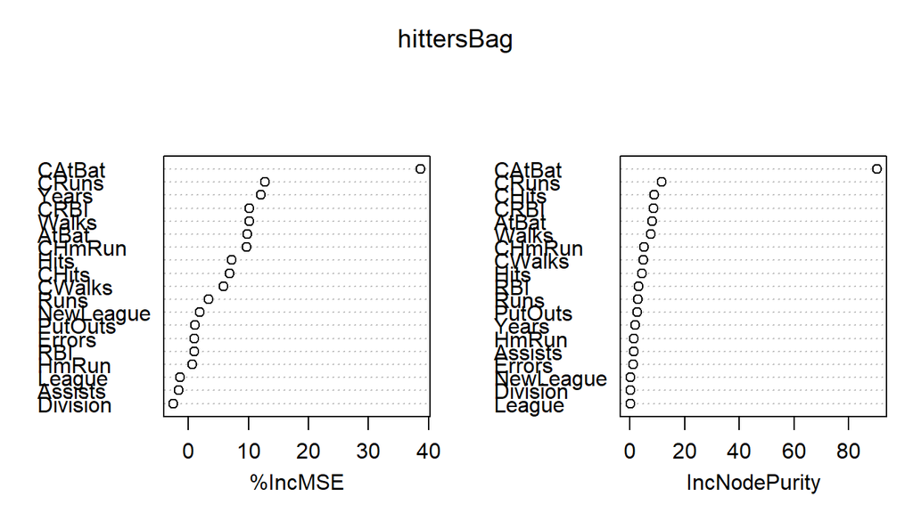

```r
varImpPlot(hittersBag)
```